# Введение в МСА. Факторный анализ

### Дата занятия: 9-10 июня

```r
library(psych)
library(lavaan)
library(semTools)
library(semPlot)
```

## 1. Данные

Источником данных является исследование Davidov E. (2009) “Measurement Equivalence of Nationalism and Constructive Patriotism in the ISSP…” Эта статья доступна по ссылке.

Ниже представлено краткое описание данных:

**VARIABLES**

- V21: The world would be a better place if people from other countries were more like the [Country Nationality]
- V22: Generally speaking, [Country] is a better country than most other countries

1 Disagree strongly

2 Disagree

3 Neither agree nor disagree

4 Agree

5 Agree strongly

- V26: How proud: The way democracy works
- V29: How proud: Its social security system
- V35: How proud: Its fair and equal treatment of all groups in society

1 Not proud at all

2 Not very proud

3 Somewhat proud

4 Very proud

Наша задача – следуя логике автора статьи, выделить факторы “национализм” и “конструктивный патриотизм”. До проведения анализа уже можно предположить, что совместная изменчивость первых двух индикаторов объясняется преимущественно фактором “национализм”, в то время как совместная изменчивость оставшихся показателей, измеряющих степень гордости тем или иным аспектом (тем, как функционирует демократия; тем, как работает система социального обеспечения; тем, как реализуется принцип честного и справедливого отношения к разным социальным группам) – фактором “патриотизм”.

Давайте откроем массив данных. В этом массиве содержатся данные только по России, такое сокращение выборки обусловлено тем, что в случае если мы работаем с опросными данными разных стран (в исходном массиве представлено порядка 30 стран), необходимо отдельное внимание уделить еще и проверке измерительной инвариантности. Дело в том, что мы не можем быть наверняка уверены, что все вопросы воспринимаются одинаковым образом респондентами из разных стран, что вне зависимости от контекста можно выделить одинаковые факторы “патриотизм” и “национализм”.

```r
df <- readRDS("tvims3_lab_FA.Rdata")
data <- subset(df, select = c(v21, v22, v26, v29, v35))
data <- na.omit(data)
```

## 2. Оправдан ли в нашем случае факторный анализ?

Для начала необходимо понять, а вообще осмысленно ли применять факторный анализ к нашим данным. Для этого посчитаем коэффициенты корреляции Спирмена между нашими переменными (наши показатели имеют порядковую шкалу). Опять же можно заметить, что наиболее сильно показатели скоррелированы внутри подгрупп: 1) V21-V22 2) V26, V29, V35.

```r
corr <- cor(data, method = "spearman")
corr
```

```
##           v21        v22        v26       v29       v35
## v21 1.0000000 0.50161861 0.16795553 0.1773607 0.2143958
## v22 0.5016186 1.00000000 0.09041993 0.1342171 0.1522645
## v26 0.1679555 0.09041993 1.00000000 0.4064133 0.4062845
## v29 0.1773607 0.13421712 0.40641334 1.0000000 0.5222880
## v35 0.2143958 0.15226446 0.40628448 0.5222880 1.0000000
```

Далее посчитаем статистику Кайзера–Майера–Олкина. Если мы наблюдаем высокие частные корреляции (взаимосвязь между двумя показателями при фиксированных остальных) по сравнению с классической корреляцией, то это означает, что наш массив достаточно фрагментарный, и вряд ли возможно выделить общие факторы, объясняющие совместную изменчивость переменных. В таком случае мы будем получать низкое значение KMO, что будет свидетельствовать о нецелесообразности применения факторного анализа.

Напоминание по градации KMO и интерпретации значений, попавших в тот или иной диапазон:

[0.9 - 1] - marvelous

[0.8 - 0.9) - meritorious

[0.7 - 0.8) - middling

[0.6 - 0.7) - mediocre

…less than 0.5 - unacceptable

```r
KMO(data)
```

```
## Kaiser-Meyer-Olkin factor adequacy
## Call: KMO(r = data)
## Overall MSA =  0.65
## MSA for each item =
##  v21  v22  v26  v29  v35
## 0.59 0.57 0.75 0.67 0.69
```

В нашем случае видим среднее значение KMO = 0.65, что в целом является приемлемым.

## 3. Разведывательный этап

На разведывательном этапе ФА мы пытаемся решаем следующие задачи:

1. определяем количество факторов
2. интерпретируем, что содержательно отражают факторы
3. делаем предварительную диагностику, определяем, в каком направлении двигаться дальше в уточнении спецификации модели

Итак, определим, сколько факторов разумно выделить.

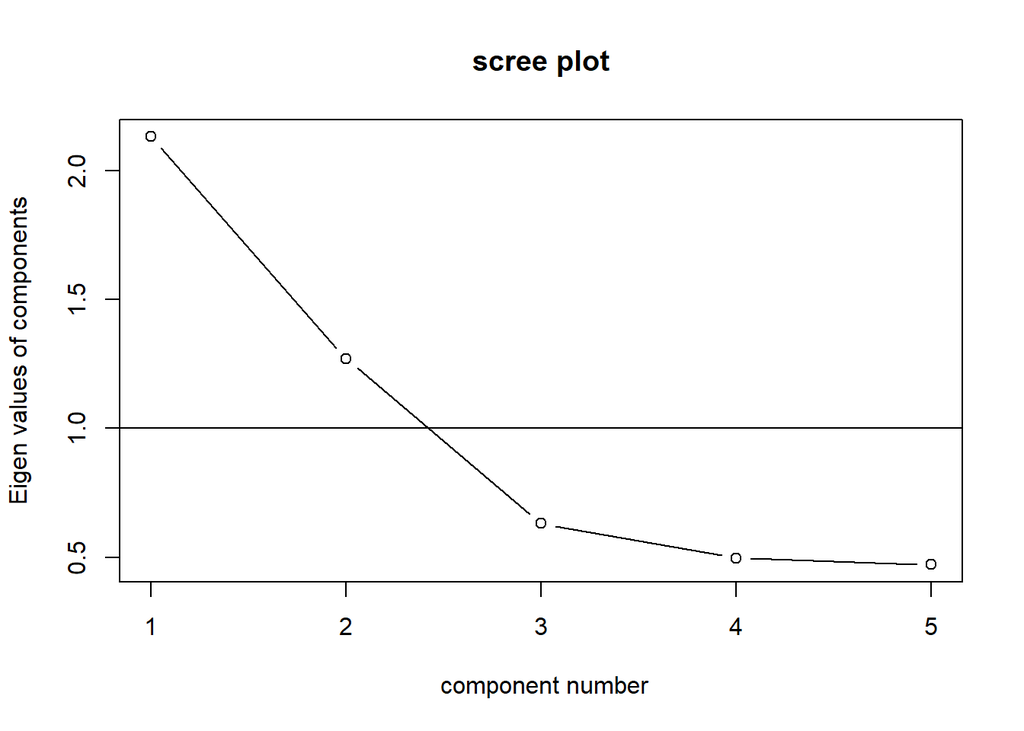

```r
VSS.scree(corr)
```

На так называемом графике каменистой осыпи мы видим, что переломная точка соответствует третьему фактору. По критерию Кайзера, два собственных значения превышают единицу, что свидетельствует о необходимости взять два фактора. Решение, основанное на двух факторах, соответствует исходной задаче выделить факторы “патриотизм” и “национализм”.

Оценим модель разведывательного ФА.

`r=corr` ниже означает, что в качестве исходных данных для реализации факторного анализа мы используем корреляционную матрицу;

`nfactors = 2` означает, что мы решили оценить модель с двумя факторами;

`fm = "pa"` показывает, что наша исходная модель оценивается посредством метода главных факторов. Данный метод похож на метод главных компонент, только в качестве исходной информации мы берем так называемую редуцированную корреляционную матрицу. В данной матрице на главной диагонали теперь стоят не единицы, а оценки общностей (предварительные оценки – квадрат множественной корреляции j-го показателя со всеми остальными показателями). Далее к такой матрице применяется МГК.

`rotate = "varimax"` применяем ортогональное вращение факторов, факторы нескоррелированы на разведывательном этапе

```r
efa1 <- fa(r = corr, nfactors = 2, fm = "pa", rotate = "varimax") # pa - principal factor FA
efa1
```

```
## Factor Analysis using method =  pa
## Call: fa(r = corr, nfactors = 2, rotate = "varimax", fm = "pa")
## Standardized loadings (pattern matrix) based upon correlation matrix
##      PA1  PA2   h2   u2 com
## v21 0.15 0.71 0.52 0.48 1.1
## v22 0.07 0.70 0.49 0.51 1.0
## v26 0.56 0.10 0.32 0.68 1.1
## v29 0.71 0.11 0.52 0.48 1.0
## v35 0.71 0.15 0.52 0.48 1.1
##
##                        PA1  PA2
## SS loadings           1.35 1.03
## Proportion Var        0.27 0.21
## Cumulative Var        0.27 0.47
## Proportion Explained  0.57 0.43
## Cumulative Proportion 0.57 1.00
##
## Mean item complexity =  1.1
## Test of the hypothesis that 2 factors are sufficient.
##
## The degrees of freedom for the null model are  10  and the objective function was  0.92
## The degrees of freedom for the model are 1  and the objective function was  0
##
## The root mean square of the residuals (RMSR) is  0.01
## The df corrected root mean square of the residuals is  0.02
##
## Fit based upon off diagonal values = 1
## Measures of factor score adequacy
##                                                    PA1  PA2
## Correlation of (regression) scores with factors   0.84 0.81
## Multiple R square of scores with factors          0.71 0.66
## Minimum correlation of possible factor scores     0.41 0.31
```

```r
print(efa1$loadings, cutoff=0.3)
```

```
##
## Loadings:
##     PA1   PA2
## v21       0.705
## v22       0.696
## v26 0.556
## v29 0.712
## v35 0.708
##
##                  PA1   PA2
## SS loadings    1.346 1.026
## Proportion Var 0.269 0.205
## Cumulative Var 0.269 0.474
```

В столбцах *PA1* и *PA2* приведены стандартизированные факторные нагрузки. Так, к примеру, 0.71 на пересечение PA2 и v21 показывает, что корреляция между вторым фактором и переменной v21 составляет 0.71.

В столбце *h2* приведены общности (доля вариации показателя, объясняемая факторами). К примеру, 0.52 в первой строке можно получить как сумму квадратов факторных нагрузок ($0.15^2 + 0.71^2$). Так, можно сказать, что факторная нагрузка в квадрате – это доля вариации, объясненная тем или фактором. $0.71^2 = 0.5041$ – то есть, примерно половину дисперсии показателя v21 объясняется вторым фактором.

В столбце *u2* приведены специфичности – та часть информации, которую мы не смогли объяснить факторами (аналог ошибок в регрессионной модели). Как мы видим, в нашем случае специфичности довольно высоки, половину информации показателей мы не смогли объяснить факторами.

Если мы сравним факторные нагрузки, то получится, что наиболее выраженные нагрузки у первого фактора – на показатели v26, v29, v35, второй же фактор наиболее скоррелирован с показателями v21 и v22. Для удобства можно вывести только те факторные нагрузки, которые превышают 0.3. Показатели v26, v29, v35 отражают гордость тем или иным аспектом (тем, как функционирует демократия; тем, как работает система социального обеспечения; тем, как реализуется принцип честного и справедливого отношения к разным социальным группам), то есть, можно сказать, что первый фактор отражает патриотизм. Второй фактор более соответствует национализму.

Для того, чтобы узнать, сколько в целом информации объясняет тот или иной фактор, необходимо посчитать сумму факторных нагрузок по соответствующему фактору. К примеру, *SS loadings* по первому фактору составляет $0.15^2 + 0.07^2 + 0.56^2 + 0.71^2 + 0.71^2 = 1.3492$. Мы можем рассчитать информативность решения: всего у нас 5 индикаторов, в силу полностью стандартизированного решения, общая исходная информация составляет 5, значит первый фактор объясняет $\dfrac{1.3492}{5} = 0.26984$

## 4. Подтверждающий этап (конфирматорный ФА)

Для начала нам нужно задать спецификацию модели, мы уже определили, с какими показателями в большей степени связаны факторы “национализм” и “патриотизм”. На подтверждающем этапе мы предполагаем отсутствие перекрестных нагрузок, что облегчает нам интерпретацию. К примеру, теперь фактор “национализм” связан не со всеми показателями, а только с v21 и v22 (задаем их в спецификации через `=~`.

При выведении результатов нам важно увидеть меры качества модели, поэтому указываем `fit.measures = TRUE`. Также выведем стандартизированное решение: `standardized = TRUE`. Данная модель оценивается уже посредством метода максимального правдоподобия.

```r
cfa1 <- 'nationalism =~ v21 + v22
patriotism =~ v26 + v29 + v35'

model1 <- cfa(cfa1, data)
summary(model1, fit.measures = TRUE, standardized = TRUE)
```

```
## lavaan 0.6-11 ended normally after 31 iterations
##
##   Estimator                                         ML
##   Optimization method                           NLMINB
##   Number of model parameters                        11
##
##   Number of observations                          1575
##
## Model Test User Model:
##
##   Test statistic                                 5.669
##   Degrees of freedom                                 4
##   P-value (Chi-square)                           0.225
##
## Model Test Baseline Model:
##
##   Test statistic                              1436.876
##   Degrees of freedom                                10
##   P-value                                        0.000
##
## User Model versus Baseline Model:
##
##   Comparative Fit Index (CFI)                    0.999
##   Tucker-Lewis Index (TLI)                       0.997
##
## Loglikelihood and Information Criteria:
##
##   Loglikelihood user model (H0)              -9867.487
##   Loglikelihood unrestricted model (H1)      -9864.652
##
##   Akaike (AIC)                               19756.973
##   Bayesian (BIC)                             19815.955
##   Sample-size adjusted Bayesian (BIC)        19781.011
##
## Root Mean Square Error of Approximation:
##
##   RMSEA                                          0.016
##   90 Percent confidence interval - lower         0.000
##   90 Percent confidence interval - upper         0.044
##   P-value RMSEA <= 0.05                          0.981
```

[output cut: 20 more lines]

```
##
## Covariances:
##                    Estimate  Std.Err  z-value  P(>|z|)   Std.lv  Std.all
##   nationalism ~~
##     patriotism        0.149    0.017    8.534    0.000    0.340    0.340
##
## Variances:
##                    Estimate  Std.Err  z-value  P(>|z|)   Std.lv  Std.all
##    .v21               0.442    0.117    3.775    0.000    0.442    0.319
##    .v22               0.905    0.076   11.949    0.000    0.905    0.618
##    .v26               0.441    0.019   22.882    0.000    0.441    0.685
##    .v29               0.262    0.018   14.329    0.000    0.262    0.466
##    .v35               0.328    0.020   16.162    0.000    0.328    0.509
##     nationalism       0.944    0.125    7.555    0.000    1.000    1.000
##     patriotism        0.203    0.020   10.098    0.000    1.000    1.000
```

Данная модель является идентифицируемой:

Количество исходных источников информации (вариации показателей и уникальные ковариации) составляет 15, а именно $\dfrac{k(k+1)}{2} = \dfrac{5\times6}{2} = 15$, где k – количество исходных показателей. В это же время мы оцениваем 11 параметров (5 факторных нагрузок, 5 специфичностей (вариаций ошибок) и 1 корреляция между факторами, так как по умолчанию R оценивает корреляцию между факторами на подтверждающем этапе). В итоге df = 4, нам хватает информации для оценивания модели с заданным количеством параметров.

В выдаче мы также можем найти несколько мер качества модели:

- SRMR (Standardized Root Mean Square Residual) - данная мера оценивает разницу между элементами исходной и предсказанной ковариационной матрицы. Хотелось бы, чтобы эта разница была меньше, что будет свидетельствовать о незначимых различиях наблюдаемых и предсказанных моделью значений. Пороговое значение составляет 0.08. Если SRMR меньше 0.08, будем считать, что качество подгонки модели приемлемо.
- RMSEA (Root Mean Square Error of Approximation) – еще одна мера качества подгонки модели. Здесь мы ориентируемся на 0.05 как пороговое значение. Если RMSEA меньше 0.05, то будем считать это приемлемым результатом. Для RMSEA дополнительно выводится 90%-ый доверительный интервал. Как мы видим, обе границы этого доверительного интервала не превышают 0.05.
- CFI (Comparative fit index) – этот индекс сравнивает данную модель с базовой моделью – случаем, непригодным для реализации факторного анализа (когда показатели нескоррелированны между собой). Для того, чтобы говорить о значимом приросте качества по сравнению с базовой моделью, этот индекс должен показывать значения близкие к единице (выше 0.95). Есть еще один индекс Такера-Льюиса (TLI), содержательно близкий к CFI, однако его значения могут выходить за пределы [0;1], так как мера TLI не является стандартизированной.

Для наглядности полученных оценок удобно изобразить путевую диаграмму.

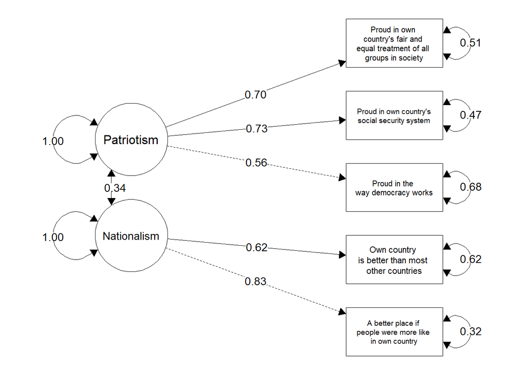

```r
semPaths(model1, "std", rotation = 2,
         nodeLabels = c("A better place if \npeople were more like \nin own country",
                        "Own country \nis better than most \nother countries",
                        "Proud in the \nway democracy works",
                        "Proud in own country's\nsocial security system",
                        "Proud in own \ncountry's fair and \nequal treatment of all \ngroups in society",
                        "Nationalism", "Patriotism"),
         colFactor = 0, sizeMan = 20, sizeMan2 = 10, sizeLat = 15, edge.color = "black",
         edge.label.cex = 1, esize = 1, mar = c(3,10,3,10))
```

`"std"` – выводим на путевой диаграмме стандартизированные оценки, более удобные для интерпретации;

`rotation = 2` – выбираем такое расположение путевой диаграммы, что латентные факторы находятся слева, а наблюдаемые индикаторы – справа;

`nodeLabels` – прописываем последовательно названия индикаторов и факторов. `\n` – обратный слэш перед n означает, что в этом месте будет перенос надписи;

`colFactor = 0` – для того, чтобы обозначить все оценки вне зависимости от их величины, одним цветом, равномерно;

`sizeMan` и `sizeMan2` – задаем длину и ширину прямоугольника для обозначения исходных индикаторов;

`sizeLat` – задаем радиус окружности для обозначения латентного фактора;

`edge.color` – цвет стрелочек;

`edge.label.cex` – размер шрифта – обозначений оценок;

`esize` – толщина стрелочек;

`mar = c(3,10,3,10)` – обозначаем поля снизу, слева, сверху и справа, соответственно

Видим, что некоторые стрелочки на путевой диаграмме пунктирные. Дело в том, что для возможности идентификации модели R по умолчанию приравнивает факторную нагрузку для одного показателя из каждого фактора единице (это можно увидеть и в нестандартизированных оценках в выдаче).

Как уже было упомянуто ранее, разведывательный этап основывается на довольно строгих и не всегда реалистичных допущениях (в частности, отсутствие корреляции между факторами, отсутствие корреляции между специфичностями). На подтверждающем этапе мы эти допущения можем ослабить. Посмотрим, какие параметры имеет смысл добавить в модель, как можно уточнить спецификацию модели. Выведем значения модификационных индексов в порядке убывания. Модификационный индекс показывает разницу между хи-квадратами для исходной более экономной модели и модели с включением того или иного параметра. Так как эти модели отличаются только на один параметр, то и MI имеет распределение хи-квадрат с одной степенью свободы. Таким образом, пороговое значения для определения значимых параметров составляет 3.84.

```r
mepc <- modindices(model1, sort. = TRUE, minimum.value = 3.84)
mepc
```

|  | lhs | op | rhs | mi | epc | sepc.lv | sepc.all | sepc.nox |
| --- | --- | --- | --- | --- | --- | --- | --- | --- |
| 15 | nationalism | =~ | v29 | 4.043211 | -0.04938958 | -0.04799514 | -0.06397348 | -0.06397348 |
| 27 | v26 | ~~ | v35 | 4.043209 | -0.05752938 | -0.05752938 | -0.15141755 | -0.15141755 |

Первый параметр `nationalism =~ v29`, который мы видим в таблице выше – это перекрестная нагрузка (корреляция национализма и показателя v29). Включение этого параметра может несколько осложнить интерпретацию. Следующий параметр `v26 ~~ v35` – корреляция между ошибками показателей v26 и v35. Дополнительно можно посмотреть на expected parameter change в столбце `sepc.all` (то есть, обращаем внимание не только на статистическую значимость, но и на величину оценки параметра, хорошо бы иметь величину не менее 0.2 по модулю).

Добавим корреляцию между специфичностями и сравним меры качества для Model 1 (более экономной модели) и Model 2 (менее экономной модели):

```r
cfa2 <- 'Nationalism =~ v21 + v22
Patriotism =~ v26 + v29 + v35
v26 ~~ v35'

model2 <- cfa(cfa2, data)
summary(model2, fit.measures = TRUE, standardized = TRUE)
```

```
## lavaan 0.6-11 ended normally after 35 iterations
##
##   Estimator                                         ML
##   Optimization method                           NLMINB
##   Number of model parameters                        12
##
##   Number of observations                          1575
##
## Model Test User Model:
##
##   Test statistic                                 1.561
##   Degrees of freedom                                 3
##   P-value (Chi-square)                           0.668
##
## Model Test Baseline Model:
##
##   Test statistic                              1436.876
##   Degrees of freedom                                10
##   P-value                                        0.000
##
## User Model versus Baseline Model:
##
##   Comparative Fit Index (CFI)                    1.000
##   Tucker-Lewis Index (TLI)                       1.003
##
## Loglikelihood and Information Criteria:
##
##   Loglikelihood user model (H0)              -9865.432
##   Loglikelihood unrestricted model (H1)      -9864.652
##
##   Akaike (AIC)                               19754.865
##   Bayesian (BIC)                             19819.209
##   Sample-size adjusted Bayesian (BIC)        19781.087
##
## Root Mean Square Error of Approximation:
##
##   RMSEA                                          0.000
##   90 Percent confidence interval - lower         0.000
##   90 Percent confidence interval - upper         0.033
##   P-value RMSEA <= 0.05                          0.996
```

[output cut: 22 more lines]

```
##                    Estimate  Std.Err  z-value  P(>|z|)   Std.lv  Std.all
##  .v26 ~~
##    .v35              -0.064    0.035   -1.812    0.070   -0.064   -0.200
##   Nationalism ~~
##     Patriotism        0.163    0.019    8.558    0.000    0.332    0.332
##
## Variances:
##                    Estimate  Std.Err  z-value  P(>|z|)   Std.lv  Std.all
##    .v21               0.426    0.118    3.611    0.000    0.426    0.307
##    .v22               0.914    0.074   12.300    0.000    0.914    0.625
##    .v26               0.392    0.034   11.488    0.000    0.392    0.610
##    .v29               0.314    0.030   10.631    0.000    0.314    0.557
##    .v35               0.259    0.044    5.837    0.000    0.259    0.403
##     Nationalism       0.960    0.126    7.624    0.000    1.000    1.000
##     Patriotism        0.251    0.036    6.963    0.000    1.000    1.000
```

```r
fitmeasures_m1_m2 <- data.frame(cbind(fitMeasures(model1, c("cfi", "rmsea", "srmr", "aic", "bic")),
                                      fitMeasures(model2, c("cfi","rmsea", "srmr", "aic", "bic"))))
colnames(fitmeasures_m1_m2) <- c("Model 1", "Model 2")
round(fitmeasures_m1_m2, digits = 3)
```

|  | Model 1 | Model 2 |
| --- | --- | --- |
| cfi | 0.999 | 1.000 |
| rmsea | 0.016 | 0.000 |
| srmr | 0.011 | 0.006 |
| aic | 19756.973 | 19754.865 |
| bic | 19815.955 | 19819.209 |

Мы видим, что RMSEA, SRMR стали ближе к 0 во второй модели, а CFI – ближе к 1. Однако и в первой модели значения мер качества были также приемлемыми. Кроме того, выведем информационные критерии AIC и BIC. Информационные критерии отражают потерю информации, чем меньше значение информационного критерия, тем лучше. Нам хотелось бы получить, с одной стороны, точную модель, с другой стороны, насколько это возможно, наиболее экономную модель. Информационные критерии накладывают штраф за добавление новых параметров (BIC – штраф выше по сравнению с AIC). Мы получили очень близкие значения как по AIC, так и по BIC, при сравнении двух моделей, поэтому можно сказать, что разница между ними статистически незначимая. Если разницы нет, то стоит выбрать более экономную модель (Model 1), мы не очень много потеряем при исключении корреляции между ошибками для показателей v26 и v35.